# stock_prediction

Import all the required python modules

```python
import warnings
warnings.filterwarnings('ignore')

import csv
import numpy
import matplotlib.pyplot as plt
import matplotlib
import pandas
import math
import requests
from fbprophet import Prophet
from keras.models import Sequential
from keras.layers import Dense, Activation
from keras.layers import LSTM
from sklearn.preprocessing import MinMaxScaler
from sklearn.metrics import mean_squared_error
from keras.callbacks import TensorBoard
from time import time
```

We download the stock data from alphavantage and write it in a csv file. After that we create dataframe from the downloaded csv file and clean up the data that is remove rows that contain zero or nan values. We observe that the data is in reverse order so we reverse the data and reset data index.

```python
data = requests.get('https://www.alphavantage.co/query?function=TIME_SERIES_DAILY&symbol=NSE:ONGC&outputsize=full&apikey=RSQGMR5WICATNF52&datatype=csv')

with open('data.csv', 'w') as f:
    writer = csv.writer(f)
    reader = csv.reader(data.text.splitlines())

    for row in reader:
        writer.writerow(row)

stock = pandas.read_csv('data.csv').dropna()
stock = stock[~(stock == 0).any(axis=1)]
stock = stock.reindex(index=stock.index[::-1])
stock = stock.reset_index(level=0)
```

Print first few rows of data to have a overview of the colums and rows in the downloaded data.

```python
stock.head()
```

|  | index | timestamp | open | high | low | close | volume |
| --- | --- | --- | --- | --- | --- | --- | --- |
| 0 | 4678 | 2000-01-03 | 22.7778 | 23.8222 | 22.7778 | 23.7167 | 86400 |
| 1 | 4677 | 2000-01-04 | 22.3889 | 23.3000 | 22.3333 | 22.9500 | 161100 |
| 2 | 4676 | 2000-01-05 | 22.3333 | 24.7889 | 22.2778 | 24.7889 | 243000 |
| 3 | 4675 | 2000-01-06 | 26.0000 | 26.1000 | 24.1778 | 24.3667 | 320400 |
| 4 | 4674 | 2000-01-07 | 24.7778 | 24.7778 | 23.6667 | 23.9722 | 102600 |

Make required colums for our model from exisiting colums in dataframe.

```python
stock['DS'] = stock['timestamp'].astype(pandas.datetime)
stock['X'] = stock['close'].astype(float)
stock['change'] = stock['close'] - stock['open']
```

```python
stock.head()
```

|  | index | timestamp | open | high | low | close | volume | DS | X | change |
| --- | --- | --- | --- | --- | --- | --- | --- | --- | --- | --- |
| 0 | 4678 | 2000-01-03 | 22.7778 | 23.8222 | 22.7778 | 23.7167 | 86400 | 2000-01-03 | 23.7167 | 0.9389 |
| 1 | 4677 | 2000-01-04 | 22.3889 | 23.3000 | 22.3333 | 22.9500 | 161100 | 2000-01-04 | 22.9500 | 0.5611 |
| 2 | 4676 | 2000-01-05 | 22.3333 | 24.7889 | 22.2778 | 24.7889 | 243000 | 2000-01-05 | 24.7889 | 2.4556 |
| 3 | 4675 | 2000-01-06 | 26.0000 | 26.1000 | 24.1778 | 24.3667 | 320400 | 2000-01-06 | 24.3667 | -1.6333 |
| 4 | 4674 | 2000-01-07 | 24.7778 | 24.7778 | 23.6667 | 23.9722 | 102600 | 2000-01-07 | 23.9722 | -0.8056 |

```python
stock.tail()
```

|  | index | timestamp | open | high | low | close | volume | DS | X | change |
| --- | --- | --- | --- | --- | --- | --- | --- | --- | --- | --- |
| 4607 | 4 | 2018-08-14 | 166.35 | 167.00 | 164.85 | 166.25 | 3791016 | 2018-08-14 | 166.25 | -0.10 |
| 4608 | 3 | 2018-08-16 | 165.90 | 166.60 | 163.85 | 164.45 | 4184404 | 2018-08-16 | 164.45 | -1.45 |
| 4609 | 2 | 2018-08-17 | 164.50 | 165.00 | 162.50 | 163.05 | 4754545 | 2018-08-17 | 163.05 | -1.45 |
| 4610 | 1 | 2018-08-20 | 164.00 | 169.90 | 164.00 | 168.70 | 9673609 | 2018-08-20 | 168.70 | 4.70 |
| 4611 | 0 | 2018-08-21 | 169.80 | 171.25 | 166.80 | 170.20 | 5181397 | 2018-08-21 | 170.20 | 0.40 |

Plot the close values of the given stock to visulaise the data.

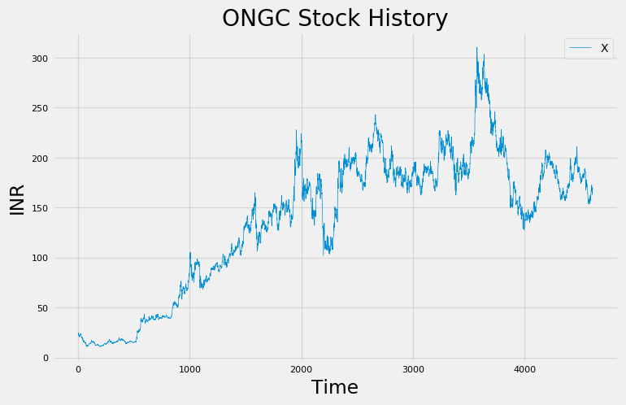

```python
matplotlib.rcParams.update(matplotlib.rcParamsDefault)
matplotlib.rcParams['figure.figsize'] = (8, 5)
matplotlib.rcParams['axes.labelsize'] = 10
matplotlib.rcParams['xtick.labelsize'] = 8
matplotlib.rcParams['ytick.labelsize'] = 8
matplotlib.rcParams['axes.titlesize'] = 14
matplotlib.rcParams['text.color'] = 'k'

plt.style.use('fivethirtyeight')
plt.plot(stock['X'], linewidth=0.5, label='X')
plt.xlabel('Time')
plt.ylabel('INR')
plt.title('%s Stock History' % 'ONGC')
plt.legend(prop={'size': 10})
plt.grid(color='k', alpha=0.1)
plt.show()
```

Extract the NumPy array from the dataframe and convert the integer values to floating point values, which are more suitable for modeling with a NN.

```python
data_frame = pandas.DataFrame(data={'X': stock['X']})
data_set = data_frame.values
data_set = data_set.astype('float32')
```

LSTMs are sensitive to the scale of the input data, specifically when the sigmoid or tanh activation functions are used. We rescale the data to the range of 0-to-1. This is also called normalizing. We will normalize the dataset using the MinMaxScaler preprocessing class from the scikit-learn library.

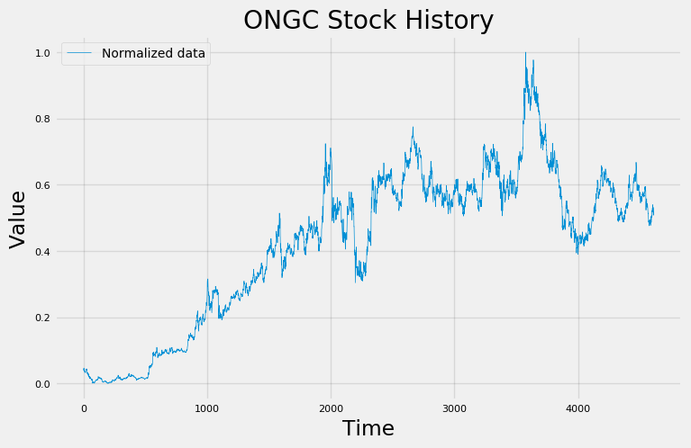

```python
scaler = MinMaxScaler(feature_range=(0, 1))
data_set = scaler.fit_transform(data_set)
plt.style.use('fivethirtyeight')
plt.plot(data_set, linewidth=0.5, label='Normalized data')
plt.xlabel('Time')
plt.ylabel('Value')
plt.title('%s Stock History' % 'ONGC')
plt.legend(prop={'size': 10})
plt.grid(color='k', alpha=0.1)
plt.show()
```

After we model our data and estimate the accuracy of our model on the training dataset, we need to get an idea of the skill of the model on new unseen data. For a normal classification or regression problem, we would do this using cross validation. With time series data, the sequence of values is important. A simple method that we used is to split the ordered dataset into train and test datasets. The code below calculates the index of the split point and separates the data into the training datasets with 75% of the observations that we can use to train our model, leaving the remaining 25% for testing the model.

```python
train_size = int(len(data_set) * 0.75)
test_size = len(data_set) - train_size
train, test = data_set[0:train_size, :], data_set[train_size:len(data_set), :]
```

We create a create data set function that takes two arguments: the dataset, which is a NumPy array that we want to convert into a dataset, and the look_back, which is the number of previous time steps to use as input variables to predict the next time period, in this case defaulted to 1.

This default will create a dataset where X is the price if the stock at a given time (t) and Y is the proce of the stock at the next time (t + 1).

```python
def create_data_set(data_set, look_back=1):
    data_x, data_y = [], []
    for i in range(len(data_set) - look_back - 1):
        a = data_set[i:(i + look_back), 0]
        data_x.append(a)
        data_y.append(data_set[i + look_back, 0])
    return numpy.array(data_x), numpy.array(data_y)
```

We create another create future data set function that takes three arguments: original data set, which is the used to fill the previous X values in the future dataset, the dataset, which is a NumPy array that we want to convert into a future dataset, and the look_back, which is the number of previous time steps to use as input variables to predict the next time period, in this case also defaulted to 1.

```python
def create_future_data_set(original_data_set, data_set, look_back=1):
    data_x, data_y = [], []
    a = original_data_set[-(look_back):, 0]
    data_x.append(a)
    data_y.append(0)
    return numpy.array(data_x), numpy.array(data_y)
```

The LSTM network expects the input data (X) to be provided with a specific array structure in the form of : [samples, time steps, features].

Currently, our data is in the form : [samples, features] and we are framing the problem as one time step for each sample. We can transform the prepared train and test input data into the expected structure using numpy.reshape()

```python
look_back = 20
train_x, train_y = create_data_set(train, look_back)
test_x, test_y = create_data_set(test, look_back)
train_x = numpy.reshape(train_x, (train_x.shape[0], 1, train_x.shape[1]))
test_x = numpy.reshape(test_x, (test_x.shape[0], 1, test_x.shape[1]))
```

```python
model = Sequential()
model.add(LSTM(32, input_shape=(1, look_back), return_sequences=True))
model.add(LSTM(16))
model.add(Dense(1))
model.add(Activation('linear'))
model.compile(loss='mean_squared_error', optimizer='adagrad')
```

```python
model.fit(train_x, train_y, epochs=5, batch_size=1, verbose=2)
```

```
 - 16s - loss: 9.5547e-04
 - 12s - loss: 5.1381e-04
 - 12s - loss: 4.0916e-04
 - 12s - loss: 3.2823e-04
 - 12s - loss: 2.8184e-04
```

```
<keras.callbacks.History at 0x1a2cc80710>
```

Once the model is fit, we can estimate the performance of the model on the train and test datasets. This will give us a point of comparison for the benchmark model.

```python
train_predict = model.predict(train_x)
test_predict = model.predict(test_x)
```

We invert the predictions before calculating error scores to ensure that performance is reported in the same units as the original data (price of stock in INR).

```python
train_predict = scaler.inverse_transform(train_predict)
train_y = scaler.inverse_transform([train_y])
test_predict = scaler.inverse_transform(test_predict)
test_y = scaler.inverse_transform([test_y])
```

Next we will calculate the erroe score that is RMSE value for the model.

```python
train_score = math.sqrt(mean_squared_error(train_y[0], train_predict[:, 0]))
print('Train Score: %.2f RMSE' % train_score)
test_score = math.sqrt(mean_squared_error(test_y[0], test_predict[:, 0]))
print('Test Score: %.2f RMSE' % test_score)
```

```
Train Score: 5.00 RMSE
Test Score: 8.16 RMSE
```

We optimize the parameters : look_back = 5, 1st LSTM layer blocks = 256, 2nd LSTM layer blocks = 128, epochs = 100, optimizer = adagrad, loss = mean_squared_error

```python
train_size = int(len(data_set) * 0.75)
test_size = len(data_set) - train_size
train, test = data_set[0:train_size, :], data_set[train_size:len(data_set), :]

batch_size = 1
look_back = 5
train_x, train_y = create_data_set(train, look_back)
test_x, test_y = create_data_set(test, look_back)
train_x = numpy.reshape(train_x, (train_x.shape[0], 1, train_x.shape[1]))
test_x = numpy.reshape(test_x, (test_x.shape[0], 1, test_x.shape[1]))

model = Sequential()
model.add(LSTM(256, input_shape=(1, look_back), return_sequences=True))
model.add(LSTM(128))
model.add(Dense(1))
model.add(Activation('linear'))
model.compile(loss='mean_squared_error', optimizer='adagrad')

tensorboard = TensorBoard(log_dir="logs/{}".format(time()))
model.fit(train_x, train_y, epochs=100, batch_size=1, verbose=2, shuffle=False, callbacks=[tensorboard])

train_predict = model.predict(train_x)
test_predict = model.predict(test_x)

train_predict = scaler.inverse_transform(train_predict)
train_y = scaler.inverse_transform([train_y])
test_predict = scaler.inverse_transform(test_predict)
test_y = scaler.inverse_transform([test_y])
```

```
 - 23s - loss: 1.2314e-04
 - 21s - loss: 1.9214e-04
 - 20s - loss: 2.0441e-04
 - 20s - loss: 1.7850e-04
 - 20s - loss: 1.5559e-04
 - 20s - loss: 1.4281e-04
 - 20s - loss: 1.3488e-04
 - 20s - loss: 1.2897e-04
 - 20s - loss: 1.2410e-04
 - 20s - loss: 1.2001e-04
 - 20s - loss: 1.1666e-04
 - 20s - loss: 1.1405e-04
 - 20s - loss: 1.1214e-04
 - 20s - loss: 1.1084e-04
 - 20s - loss: 1.1004e-04
 - 20s - loss: 1.0963e-04
 - 20s - loss: 1.0953e-04
 - 21s - loss: 1.0963e-04
 - 20s - loss: 1.0988e-04
 - 20s - loss: 1.1021e-04
 - 21s - loss: 1.1058e-04
 - 20s - loss: 1.1097e-04
 - 20s - loss: 1.1136e-04
 - 20s - loss: 1.1172e-04
 - 20s - loss: 1.1205e-04
 - 20s - loss: 1.1234e-04
 - 20s - loss: 1.1259e-04
 - 20s - loss: 1.1280e-04
 - 20s - loss: 1.1297e-04
 - 20s - loss: 1.1310e-04
 - 20s - loss: 1.1320e-04
 - 20s - loss: 1.1326e-04
 - 20s - loss: 1.1328e-04
 - 20s - loss: 1.1328e-04
 - 21s - loss: 1.1326e-04
 - 20s - loss: 1.1321e-04
 - 20s - loss: 1.1314e-04
 - 20s - loss: 1.1306e-04
 - 20s - loss: 1.1296e-04
 - 20s - loss: 1.1284e-04
```

[output cut: 45 more lines]

```
 - 22s - loss: 1.0664e-04
 - 22s - loss: 1.0656e-04
 - 21s - loss: 1.0647e-04
 - 22s - loss: 1.0639e-04
 - 20s - loss: 1.0630e-04
 - 20s - loss: 1.0622e-04
 - 20s - loss: 1.0614e-04
 - 20s - loss: 1.0606e-04
 - 20s - loss: 1.0599e-04
 - 20s - loss: 1.0591e-04
 - 20s - loss: 1.0584e-04
 - 21s - loss: 1.0577e-04
 - 20s - loss: 1.0570e-04
 - 20s - loss: 1.0563e-04
 - 20s - loss: 1.0556e-04
```

We will calculate the error score for the improved model.

```python
train_score = math.sqrt(mean_squared_error(train_y[0], train_predict[:, 0]))
print('Train Score: %.2f RMSE' % train_score)
test_score = math.sqrt(mean_squared_error(test_y[0], test_predict[:, 0]))
print('Test Score: %.2f RMSE' % test_score)
```

```
Train Score: 4.29 RMSE
Test Score: 5.84 RMSE
```

Finally, we generate predictions using the model for both the train and test dataset to get a visual indication of the skill of the model.

Because of how the dataset was prepared, we will shift the predictions so that they align on the x-axis with the original dataset. Once prepared, the data is plotted, showing the original dataset in blue, the predictions for the training dataset in red, and the predictions on the unseen test dataset in yellow.

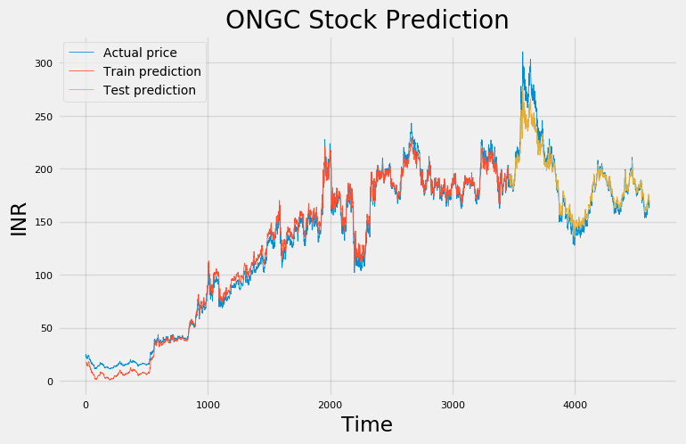

```python
matplotlib.rcParams.update(matplotlib.rcParamsDefault)
matplotlib.rcParams['figure.figsize'] = (8, 5)
matplotlib.rcParams['axes.labelsize'] = 10
matplotlib.rcParams['xtick.labelsize'] = 8
matplotlib.rcParams['ytick.labelsize'] = 8
matplotlib.rcParams['axes.titlesize'] = 14
matplotlib.rcParams['text.color'] = 'k'

# shift train predictions for plotting
train_predict_plot = numpy.empty_like(data_set)
train_predict_plot[:, :] = numpy.nan
train_predict_plot[look_back:len(train_predict) + look_back, :] = train_predict
# shift test predictions for plotting
test_predict_plot = numpy.empty_like(data_set)
test_predict_plot[:, :] = numpy.nan
test_predict_plot[len(train_predict) + (look_back * 2) + 1:len(data_set) - 1, :] = test_predict
# plot baseline and predictions
plt.style.use('fivethirtyeight')
plt.plot(scaler.inverse_transform(data_set), linewidth=0.6, label='Actual price')
plt.plot(train_predict_plot, linewidth=0.6, label='Train prediction')
plt.plot(test_predict_plot, linewidth=0.6, label='Test prediction')
plt.title('%s Stock Prediction' % 'ONGC')
plt.xlabel('Time')
plt.ylabel('INR')
plt.legend(prop={'size': 10})
plt.grid(color='k', alpha=0.1)
plt.show()
```

We train our model on all the data that is availabe. We find the RMSE for the training data to have some sort of metric to measure and predict the value of the stock one day in future.

```python
train_size = int(len(data_set))
train = data_set[0:train_size, :]

batch_size = 1
look_back = 5
future_data_set = numpy.zeros((look_back + 2, 1))

train_x, train_y = create_data_set(train, look_back)
future_x, future_y = create_future_data_set(data_set, future_data_set, look_back)
train_x = numpy.reshape(train_x, (train_x.shape[0], 1, train_x.shape[1]))
future_x = numpy.reshape(future_x, (future_x.shape[0], 1, future_x.shape[1]))

model = Sequential()
model.add(LSTM(256, input_shape=(1, look_back), return_sequences=True))
model.add(LSTM(128))
model.add(Dense(1))
model.add(Activation('linear'))
model.compile(loss='mean_squared_error', optimizer='adagrad')

model.fit(train_x, train_y, epochs=100, batch_size=1, verbose=2, shuffle=False)

train_predict = model.predict(train_x, batch_size=1)
train_predict = scaler.inverse_transform(train_predict)
train_y = scaler.inverse_transform([train_y])

future_predict = model.predict(future_x, batch_size=1)
future_predict = scaler.inverse_transform(future_predict)
future_y = scaler.inverse_transform([future_y])

train_score = math.sqrt(mean_squared_error(train_y[0], train_predict[:, 0]))
print('\nTrain Score: %.2f RMSE' % train_score)

print('Previous day actual value: INR %.2f' % scaler.inverse_transform(data_set)[-1])
print('Previous day predicted value: INR %.2f' % train_predict[-1])
print('Next day predicted value: INR %.2f' % future_predict)
```

```
 - 30s - loss: 1.3906e-04
 - 28s - loss: 2.0301e-04
 - 30s - loss: 2.1677e-04
 - 27s - loss: 1.9052e-04
 - 30s - loss: 1.6658e-04
 - 27s - loss: 1.5290e-04
 - 27s - loss: 1.4470e-04
 - 27s - loss: 1.3906e-04
 - 28s - loss: 1.3481e-04
 - 30s - loss: 1.3148e-04
 - 29s - loss: 1.2890e-04
 - 30s - loss: 1.2697e-04
 - 29s - loss: 1.2560e-04
 - 28s - loss: 1.2470e-04
 - 28s - loss: 1.2419e-04
 - 27s - loss: 1.2398e-04
 - 27s - loss: 1.2400e-04
 - 27s - loss: 1.2419e-04
 - 29s - loss: 1.2449e-04
 - 28s - loss: 1.2486e-04
 - 29s - loss: 1.2528e-04
 - 29s - loss: 1.2571e-04
 - 30s - loss: 1.2614e-04
 - 29s - loss: 1.2655e-04
 - 27s - loss: 1.2693e-04
 - 28s - loss: 1.2728e-04
 - 28s - loss: 1.2760e-04
 - 29s - loss: 1.2787e-04
 - 28s - loss: 1.2811e-04
 - 30s - loss: 1.2832e-04
 - 27s - loss: 1.2848e-04
 - 27s - loss: 1.2861e-04
 - 30s - loss: 1.2871e-04
 - 30s - loss: 1.2878e-04
 - 29s - loss: 1.2882e-04
 - 30s - loss: 1.2884e-04
 - 29s - loss: 1.2883e-04
 - 30s - loss: 1.2881e-04
 - 30s - loss: 1.2876e-04
 - 30s - loss: 1.2870e-04
```

[output cut: 50 more lines]

```
 - 30s - loss: 1.2189e-04
 - 31s - loss: 1.2179e-04
 - 30s - loss: 1.2169e-04
 - 30s - loss: 1.2160e-04
 - 31s - loss: 1.2150e-04
 - 30s - loss: 1.2141e-04
 - 29s - loss: 1.2132e-04
 - 28s - loss: 1.2123e-04
 - 30s - loss: 1.2114e-04
 - 29s - loss: 1.2106e-04

Train Score: 7.83 RMSE
Previous day actual value: INR 170.20
Previous day predicted value: INR 163.14
Next day predicted value: INR 169.84
```

Prepare data for benchmark model and split into train and test data.

```python
stock['ds'] = stock['timestamp']
stock['y'] = stock['close'].astype(float)

train_size_prophet = int(len(stock) * 0.75)
test_size_prophet = len(stock) - train_size

train_prophet = stock[:train_size_prophet]
test_prophet = stock[train_size_prophet:]
```

Create prophet model, train the model on train data and make predictions on train and test data.

```python
prophet_model = Prophet()
prophet_model.daily_seasonality=True

prophet_model.fit(train_prophet)

train_predict_prophet = prophet_model.predict(train_prophet)
test_predict_prophet = prophet_model.predict(test_prophet)
```

Calculate the RMSE for training and testing data.

```python
train_score_prophet = math.sqrt(mean_squared_error(train_prophet['y'], train_predict_prophet['yhat']))
print('Train Score: %.2f RMSE' % train_score_prophet)
test_score_prophet = math.sqrt(mean_squared_error(test_prophet['y'], test_predict_prophet['yhat']))
print('Test Score: %.2f RMSE' % test_score_prophet)
```

```
Train Score: 13.11 RMSE
Test Score: 39.45 RMSE
```

Train the model again with all the data available and predict the future value of the given stock using the prophet model one day in future.

```python
prophet_model = Prophet()
prophet_model.daily_seasonality=True

prophet_model.fit(stock)
train_predict = prophet_model.predict(stock)

train_score_prophet = math.sqrt(mean_squared_error(stock['y'], train_predict['yhat']))
print('Train Score: %.2f RMSE' % train_score_prophet)

future = prophet_model.make_future_dataframe(periods=1, freq='D')
forecast = prophet_model.predict(future)
print('Next day predicted value: INR %.2f' % forecast.tail(1)['yhat'])
```

```
Train Score: 20.34 RMSE
Next day predicted value: INR 156.10
```